# R for Spatial Analysis Demonstration

Jeff Hollister

2020-04-28

# R for Spatial Analysis

Not too long ago, the standard advice for mixing spatial analysis and R was to do your spatial analysis tasks with a GIS and your statistical analysis of the results of that analysis with R. However, since the mid 2000’s there has been a rapid increase in the spatial data handling and analysis capability of R. The `rgdal`, `rgeos`, `raster`, and `sp` packages (through the very significant effort of the package authors) provided the foundation for doing GIS entirely within R. More recently a new route for handling vector data has emerged in the [`sf` package](https://cran.r-project.org/package=sf). Most current development for vector processing is focusing on `sf`. Raster data is still mostly dealt with via the [`raster`](https://cran.r-project.org/package=raster) package, although this is changing rapidly as development on the [`terra`](https://cran.r-project.org/package=terra) and [`stars`](https://cran.r-project.org/package=stars) packages is moving along quickly.

## Basics: Vector and raster data

Before we dig into the packages, I want to do a bit of some basics just to make sure everyone is on the same page with the most common types of spatial data: vector and raster. It is important to understand this when working with spatial data as the tooling for working with the data will be different when using vector vs raster data. This is the case across all software and not specific to R.

Vector data is data that represents features with discrete locations and can be used to show things like points (e.g. species locations, fire hydrants), lines (e.g. roads, streams), or polygons (e.g. lakes, state boundaries). On the other hand, raster data breaks up the world into pixels. For each pixel we have a location and then a value for that pixel to indicated if it is a hydrant, a road, a stream, a lake, etc. See the example below:

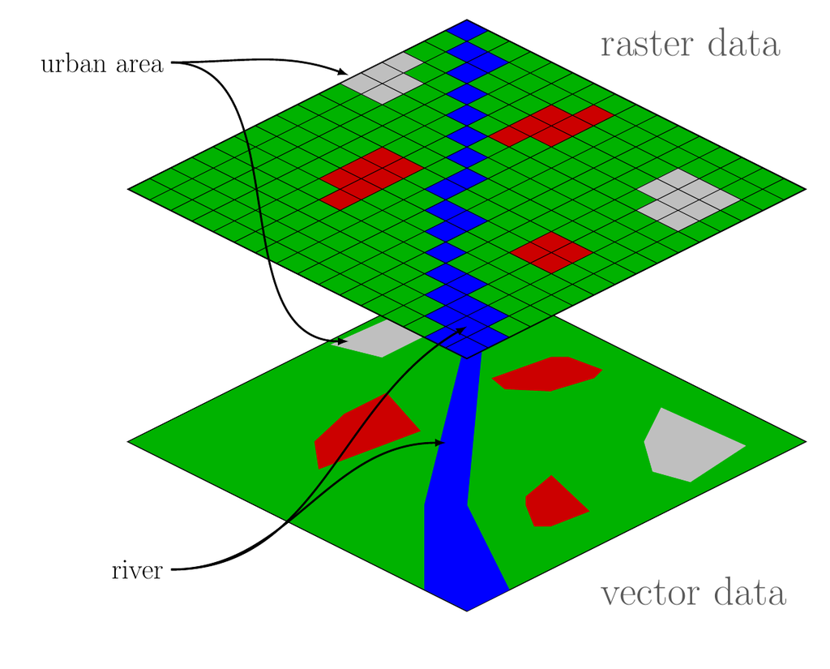

source: https://commons.wikimedia.org/wiki/File:Raster_vector_tikz.png

## Spatial software ecosystem

Before we get to the R packages we need to discuss a bit about the underlying software libraries that make all of this GIS and spatial data analysis in R possible. The three primary pieces of software are the [Geospatial Data Abstraction Library (GDAL)](https://www.osgeo.org/projects/gdal/), [Geometry Engine - Open Source (GEOS)](https://www.osgeo.org/projects/geos/), and [PROJ](https://www.osgeo.org/projects/proj/) and are all projects of the Open Source GeoSpatial Foundation and provide Input/Ouput for many different file types, topology and spatial operations, and coordinate tranformation functionality, respecitvely. These are the libraries that provide much of the funtionality for many open source GIS and spatial analysis software.

In R, these three software libraries are accessed and made available via several packages. The primary ones are discussed below.

### sf

The [`sf` package](http://r-spatial.github.io/sf/) provides vector data handling via the Simple Features standard, an Open Geospatial Consortium and International Standards Organization standard for spatial data. In addition, `sf` provides a tidy spatial data format that allows for manipulation with the popular `dplyr` package.

On Windows, getting `sf` added is no different than adding any other package that is on CRAN. If you are on linux or macOS then you’ll need to put in a bit more effort (i.e. need to have GDAL and GEOS installed). Best instructions for getting all this set up are at https://github.com/r-spatial/sf#installing. If you are on macOS, you will need XCode and `homebrew` installed. To do so, open up a Terminal window the type:

```
xcode-select --install
```

Once that finishes we can get the latest version of `homebrew` with this incantation:

```
ruby -e "$(curl -fsSL https://raw.githubusercontent.com/Homebrew/install/master/install)"
```

Copy and paste this, hit return and then you should be ready to get the libraries needed for `sf`. With `homebrew` installed, we can now install what we need; gdal and geos.

```
brew install gdal
brew install geos
```

If you are on linux, I’ll assume you can get gdal and geos on your own!

In theory, we should be good to install `sf` now:

```r
install.packages("sf")
library("sf")
```

You get a lot with `sf`. It provides the ability to work with a very wide array of spatial data formats (eg. points, lines, polygons, geometry collections, and more) plus many of the standard GIS functionalities (overlays, buffers, projections, etc.). One other package to be aware of that I have used often in conjunction with `sf` is [`lwgeom`](https://r-spatial.github.io/lwgeom/) which provides some additional functionality, but we won’t be looking at that one today.

### raster, stars, and terra

For our raster data processing I will mostly be using the venerable `raster` package.

To install, just do:

```r
install.packages("raster")
library("raster")
```

The [`raster` package](https://rspatial.org/raster/index.html) has been around for some time and provides a lot of raster functionality. It has been extended with other packages such as `gdistance` which provides the ability to work with cost surfaces in R, and `landsat` which provides tools to process Landsat data. Similar to how `sf` recently replaced some older packages, a few new packages are being developed that likely will eventually replace `raster`. Two to be aware of are `terra` and `stars`. The development of the `terra` package is being led by Robert Hijmans (the author of `raster`) and according to the [repository](https://github.com/rspatial/terra) promises to have a, “very similar, but simpler, interface” and should be, “much faster.” The [`stars` package](https://r-spatial.github.io/stars/), led by Edzer Pebesma, also the lead for `sf`, is for multi-dimensional spatiotemporal arrays. It largely has a different niche than `raster` or `terra` so is perhaps a compliment, but I’d expect there to be some degree of overlap.

Installation of both packages is available from CRAN.

```r
install.packages(c("stars","terra"))
library("stars")
library("terra")
```

## Aside: Interacting with an external GIS

Although we won’t be working with external GIS in this workshop, there are several packages that provide ways to move back and forth from another GIS and R.

- [spgrass6](https://cran.r-project.org/web/packages/spgrass6/index.html): Provides an interface between R and [GRASS 6+](https://grass.osgeo.org/download/software/#g64x). Allows for running R from within GRASS as well as running GRASS from within R.
- [rgrass7](https://cran.r-project.org/web/packages/rgrass7/index.html): Same as `spgrass6`, but for the latest version of GRASS, [GRASS 7](https://grass.osgeo.org/download/software/#g70x).
- [RPyGeo](https://cran.r-project.org/web/packages/RPyGeo/index.html): A wrapper for accessing ArcGIS from R. Utilizes intermediate python scripts to fire up ArcGIS. Hasn’t been updated in some time.
- [RSAGA](https://cran.r-project.org/web/packages/RSAGA/index.html): R interface to the command line version of [SAGA GIS](http://www.saga-gis.org/en/index.html).
- RQGIS: Provides an interface to [QGIS](http://www.qgis.org/en/site/) from R.

## Mapping packages

There are many different packages available for creating maps in R, in the demos to come we will focus on two packages, `ggplot2` and `mapview`, in addition to the default plotting that `sf` and `raster` provide.

To make sure these are installed:

```r
install.packages("ggplot2")
library("ggplot2")
install.packages("mapview")
library("mapview")
```

We will use `ggplot2` to build static maps, and use `mapview` for interactive maps. In addition to these, it probably pays to be aware of a few others that are commonly used for mapping.

- [`leaflet`](https://rstudio.github.io/leaflet/): R wrapper for the Leaflet javascript library. The `mapview` package is actually a wrapper (in-part) around this pacakge
- [`tmap`](https://github.com/mtennekes/tmap): Built for making thematic maps and has built in support to scale bars, north arrows, etc.
- [`ggmap`](https://github.com/dkahle/ggmap): Built on top of `ggplot2`, `ggmap` allows for combining spatial data with map tiles from sources such as Goolge Maps or Stamen Maps.

## Useful resources

In addition to the resources and links already provide, there are three really nice resources that are my first stops for learning how to use R for spatial data analysis.

- [Geocomputation with R](https://geocompr.robinlovelace.net/)
- [r-spatial](https://www.r-spatial.org/)
- [rspatial](https://www.rspatial.org/)

*note: All involved are aware of the confusing “r-spatial” vs “rspatial” naming. Probably not going to change anytime soon. They both serve as useful resources and the authors of both are, in spite of what the naming suggests, working fairly closely together to improve spatial analysis capabilities in R.*